# Forecasting Total Supplier Services Using ARIMA and Prophet

## Key Observations

```python
# Re-aggregate by year (already indexed) and region for yearly data
combined_services_yearly = combined_data.groupby([combined_data.index.year, 'Rfrg_Prvdr_Geo_Desc'])['Tot_Suplr_Srvcs'].sum().reset_index()
combined_services_yearly.rename(columns={'Year': 'Year', 'Rfrg_Prvdr_Geo_Desc': 'Region', 'Tot_Suplr_Srvcs': 'Total_Services'}, inplace=True)

# Convert Date to datetime format
combined_services_yearly['Date'] = pd.to_datetime(combined_services_yearly['Year'], format='%Y')

# Preview the yearly aggregated dataset
combined_services_yearly.head()
```

|  | Year | Region | Total_Services | Date |
| --- | --- | --- | --- | --- |
| 0 | 2014 | Alabama | 35494581 | 2014-01-01 |
| 1 | 2014 | Alaska | 1378350 | 2014-01-01 |
| 2 | 2014 | American Samoa | 99 | 2014-01-01 |
| 3 | 2014 | Arizona | 17722849 | 2014-01-01 |
| 4 | 2014 | Arkansas | 22041433 | 2014-01-01 |

```python
# Identify the top 5 regions by cumulative Total Services
top_regions = combined_services_yearly.groupby('Region')['Total_Services'].sum().nlargest(5).index.tolist()

# Filter data for only the top 5 regions
top_regions_data = combined_services_yearly[combined_services_yearly['Region'].isin(top_regions)]

# Display the top 5 regions
top_regions
```

```
['National', 'California', 'Texas', 'Florida', 'New York']
```

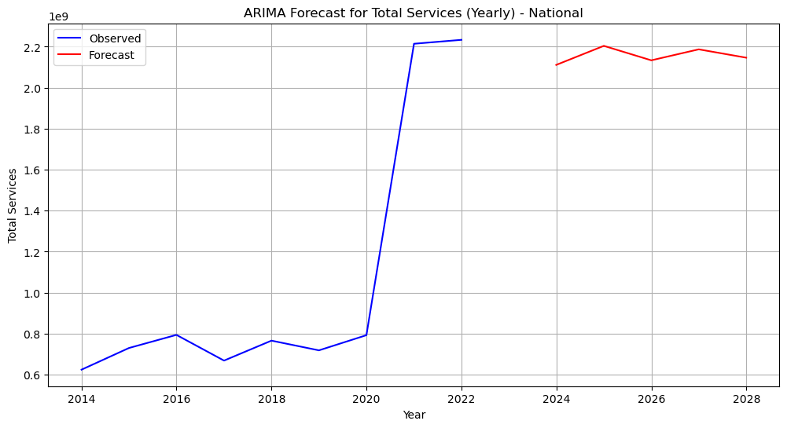

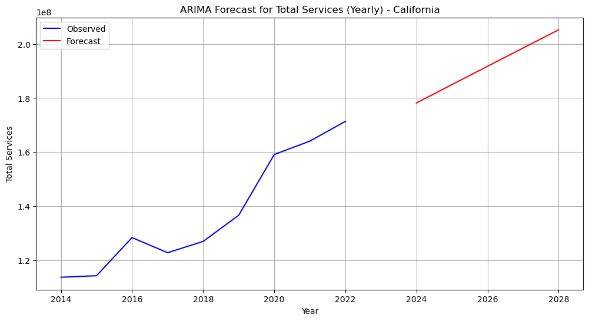

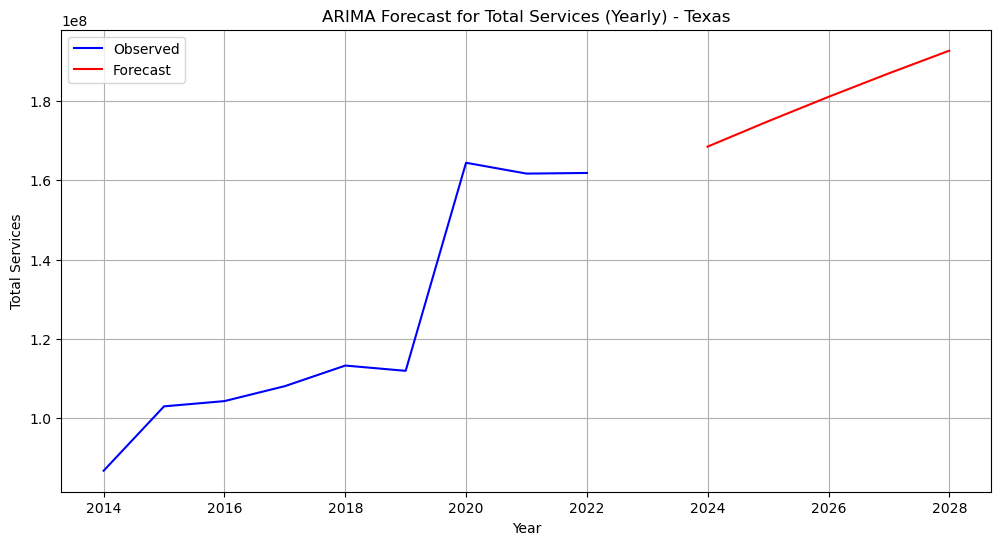

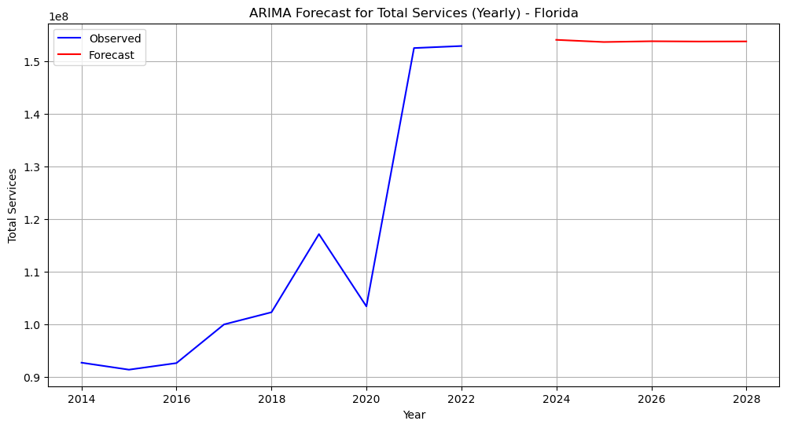

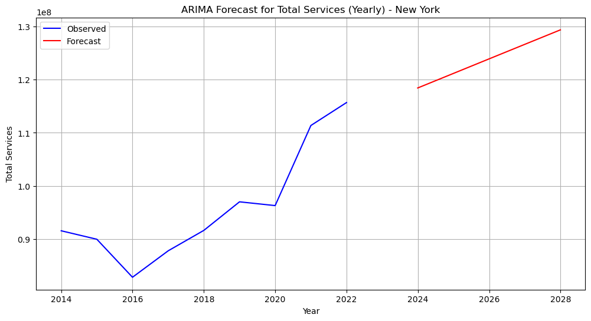

```
ARIMA forecasts saved to 'arima_services_output.csv'
```

```python
# Forecast Total Services using ARIMA for the top 5 regions
arima_forecasts = {}

for region in top_regions:
    # Filter data for the region
    region_data = top_regions_data[top_regions_data['Region'] == region].set_index('Date')

    # Fit ARIMA model
    arima_model = ARIMA(region_data['Total_Services'], order=(1, 1, 1))  # Adjust order if necessary
    arima_model_fit = arima_model.fit()

    # Forecast for the next 5 years
    forecast = arima_model_fit.forecast(steps=5)
    arima_forecasts[region] = forecast

    # Plot observed and forecasted values
    plt.figure(figsize=(12, 6))
    plt.plot(region_data['Total_Services'], label='Observed', color='blue')
    plt.plot(pd.date_range(region_data.index[-1], periods=6, freq='Y')[1:], forecast, label='Forecast', color='red')
    plt.title(f"ARIMA Forecast for Total Services (Yearly) - {region}")
    plt.xlabel('Year')
    plt.ylabel('Total Services')
    plt.legend()
    plt.grid(True)
    plt.show()

# Combine Prophet forecasts into a single DataFrame
arima_forecasts_df = pd.concat(
    [forecast.assign(Region=region)[['Region', 'ds', 'yhat', 'yhat_lower', 'yhat_upper']]
     for region, forecast in prophet_forecasts.items()],
    ignore_index=True
)

# Save to CSV
arima_forecasts_df.to_csv('arima_services_output.csv', index=False)
print("ARIMA forecasts saved to 'arima_services_output.csv'")
```

## ARIMA Forecast for Total Supplier Services (Yearly)

## Key Observations by Region

### **National**

- **Observed Trend**: A sharp increase in total services around 2020, stabilizing afterward.
- **Forecast**: Services are expected to remain stable at approximately **2.2 billion** from 2024 onward, indicating no significant growth or decline.

### **Florida**

- **Observed Trend**: Irregular growth with a sharp rise around 2020, stabilizing thereafter.
- **Forecast**: Services remain steady at approximately **150 million**, with no major changes predicted.

### **New York**

- **Observed Trend**: Gradual growth from 2014, with a notable increase post-2020.
- **Forecast**: A steady increase is expected, reaching approximately **130 million** by 2028.